# Programming Lab #2

DS 3001: Introduction to Machine Learning

Andrew Holzwarth, Brian Bippert, Felipe Martinez, Garrett Burroughs, Tyler Lynch

## Data

- `age`: numeric ranging from 0.08 to 82
  - A bin was created for ages greater than 69 and less than or equal to 68
- `avg_glucose_level`: numeric representing glucose level
  - A bin was created for glucose greater than 190 and less than or equal to 189
- `bmi`: character representing bmi, contained NAs that were omitted, and converted to a numeric
- `ever_married`: categorical character variable, converted to a dummy numeric variable
- `gender`: categorical character variable, converted to a dummy numeric variable
- `heart_disease`: dummy numeric variable, left unchanged
- `hypertension`: dummy numeric variable, left unchanged
- `id`: removed from our data as it is directly correlated to stroke
- `Residence_type`: categorical character variable, converted to a dummy numeric variable
- `smoking_status`: categorical character variable, converted to dummy numeric variable based on smoking status
- `work_type`: dummy character variable, left unchanged
- `stroke`: target variable, dummy numeric variable

#### Wrangling the data

The first step we took in preparing the dataset was to remove the variables `id` and `X`. These were just labels for the observations, but they were directly correlated to `stroke` as they were listed in order, with all the stroke cases being listed after all the non-stroke cases. All other variables were left in, although `gender`, `ever_married`, and `Residence_type` were all converted to dummy variables. The `smoking_status` variable was also converted to a binary dummy variable despite having more than two inputs. If the person had formerly smoked or currently smokes, they were assigned a `1`. All other values were given a `0`. `BMI` was converted to a numeric vector as the original dataset has it as a character. Lastly, all `NA`s were omitted, which was only from the `BMI` variable, and were few enough to allow this omission.

#### Interactions

The variables that were interacted were the `age` bins and the `glucose_level` bins. This new variable was then interacted again with the `smoking_status` bins. Both interacted variables were added to the dataframe. These choices were made by observing patterns in the data. By looking through the data, it can be seen that those over a certain age and with high glucose are almost certain to have a stroke. Additionally, if this person has a history of smoking, that probability is ever higher. These interactions significantly increase the model’s effectiveness at predicting if older individuals will have a stroke.

#### kNN

```
##   gender       age hypertension heart_disease ever_married work_type
## 1    0.5 0.4384766            0             0            1      0.25
## 2    0.0 0.5483398            0             0            1      0.25
## 3    0.5 0.7070312            0             0            0      1.00
## 4    0.0 0.7436523            0             0            1      1.00
## 5    0.0 0.9511719            0             0            0      0.75
## 6    0.5 0.4140625            0             0            0      0.75
##   Residence_type avg_glucose_level       bmi smoking_status stroke
## 1              1        0.04962607 0.2508591      0.0000000      0
## 2              0        0.06250577 0.1718213      0.3333333      0
## 3              0        0.53462284 0.2336770      1.0000000      0
## 4              1        0.06813775 0.1924399      0.3333333      0
## 5              1        0.22500231 0.2325315      1.0000000      0
## 6              1        0.24628381 0.2302405      0.6666667      0
```

#### kMC

```
##                         gender         age hypertension heart_disease
## gender             1.000000000 -0.04041892  0.018453361  0.0786300774
## age               -0.040418923  1.00000000  0.277990977  0.2563186287
## hypertension       0.018453361  0.27799098  1.000000000  0.1001206130
## heart_disease      0.078630077  0.25631863  0.100120613  1.0000000000
## ever_married      -0.042242776  0.67105215  0.165596901  0.1107189089
## work_type         -0.077561583  0.53466137  0.130268992  0.0863524484
## Residence_type    -0.008140455  0.01136681 -0.007267459  0.0003276716
## avg_glucose_level  0.050345400  0.23469468  0.182172772  0.1476716699
## bmi               -0.028082955  0.33194103  0.174681760  0.0415473834
## smoking_status     0.039784886 -0.37986749 -0.123462316 -0.0564752593
## stroke             0.009688199  0.23107937  0.145850709  0.1429657823
##                   ever_married   work_type Residence_type avg_glucose_level
## gender            -0.042242776 -0.07756158  -0.0081404552      0.0503453999
## age                0.671052149  0.53466137   0.0113668116      0.2346946776
## hypertension       0.165596901  0.13026899  -0.0072674587      0.1821727717
## heart_disease      0.110718909  0.08635245   0.0003276716      0.1476716699
## ever_married       1.000000000  0.41806682   0.0036639709      0.1410892019
## work_type          0.418066816  1.00000000  -0.0113127142      0.0881576544
## Residence_type     0.003663971 -0.01131271   1.0000000000     -0.0005208221
## avg_glucose_level  0.141089202  0.08815765  -0.0005208221      1.0000000000
## bmi                0.338139838  0.33234118  -0.0023090609      0.1727829396
## smoking_status    -0.302831615 -0.33124728  -0.0019414873     -0.1059477291
## stroke             0.097565298  0.08040518  -0.0020080158      0.1404654793
##                            bmi smoking_status       stroke
## gender            -0.028082955    0.039784886  0.009688199
## age                0.331941035   -0.379867495  0.231079369
## hypertension       0.174681760   -0.123462316  0.145850709
## heart_disease      0.041547383   -0.056475259  0.142965782
## ever_married       0.338139838   -0.302831615  0.097565298
## work_type          0.332341180   -0.331247282  0.080405178
## Residence_type    -0.002309061   -0.001941487 -0.002008016
## avg_glucose_level  0.172782940   -0.105947729  0.140465479
## bmi                1.000000000   -0.237798166  0.039535070
## smoking_status    -0.237798166    1.000000000 -0.070384330
## stroke             0.039535070   -0.070384330  1.000000000
```

#### Linear Model

```r
#import data
df_train <- read.csv("training_data.csv")
df_test <- read.csv("testing_data.csv")
#data wrangle
df_train <- df_train[-c(1,2)]
df_test <- df_test[-c(1,2)]
df_train$bmi = as.numeric(df_train$bmi)
df_test$bmi = as.numeric(df_test$bmi)
df_train$gender <- ifelse(df_train$gender == "Male",1,0)
df_train$ever_married <- ifelse(df_train$ever_married == "Yes",1,0)
df_train$Residence_type <- ifelse(df_train$Residence_type == "Urban",1,0)
df_test$gender <- ifelse(df_test$gender == "Male",1,0)
df_test$ever_married <- ifelse(df_test$ever_married == "Yes",1,0)
df_test$Residence_type <- ifelse(df_test$Residence_type == "Urban",1,0)
df_train <- na.omit(df_train)
df_test <- na.omit(df_test)
summary(df_train)
```

```
##      gender            age         hypertension     heart_disease
##  Min.   :0.0000   Min.   : 0.08   Min.   :0.00000   Min.   :0.00000
##  1st Qu.:0.0000   1st Qu.:25.00   1st Qu.:0.00000   1st Qu.:0.00000
##  Median :0.0000   Median :44.00   Median :0.00000   Median :0.00000
##  Mean   :0.4099   Mean   :42.99   Mean   :0.09343   Mean   :0.05117
##  3rd Qu.:1.0000   3rd Qu.:60.00   3rd Qu.:0.00000   3rd Qu.:0.00000
##  Max.   :1.0000   Max.   :82.00   Max.   :1.00000   Max.   :1.00000
##   ever_married     work_type         Residence_type   avg_glucose_level
##  Min.   :0.0000   Length:3928        Min.   :0.0000   Min.   : 55.12
##  1st Qu.:0.0000   Class :character   1st Qu.:0.0000   1st Qu.: 77.15
##  Median :1.0000   Mode  :character   Median :1.0000   Median : 91.85
##  Mean   :0.6538                      Mean   :0.5018   Mean   :105.14
##  3rd Qu.:1.0000                      3rd Qu.:1.0000   3rd Qu.:113.25
##  Max.   :1.0000                      Max.   :1.0000   Max.   :271.74
##       bmi        smoking_status         stroke
##  Min.   :10.30   Length:3928        Min.   :0.00000
##  1st Qu.:23.60   Class :character   1st Qu.:0.00000
##  Median :28.10   Mode  :character   Median :0.00000
##  Mean   :28.92                      Mean   :0.04353
##  3rd Qu.:33.10                      3rd Qu.:0.00000
##  Max.   :97.60                      Max.   :1.00000
```

```r
N = dim(df_train)[1] + dim(df_test)[1]
```

```r
#Linear Model 1
lazy_lm <- lm(stroke~.,data=df_train)
summary(lazy_lm)
```

```
##
## Call:
## lm(formula = stroke ~ ., data = df_train)
##
## Residuals:
##      Min       1Q   Median       3Q      Max
## -0.30569 -0.06871 -0.02126  0.00522  1.00387
##
## Coefficients:
##                              Estimate Std. Error t value Pr(>|t|)
## (Intercept)                -2.745e-02  1.807e-02  -1.519 0.128876
## gender                     -3.831e-04  6.445e-03  -0.059 0.952613
## age                         2.610e-03  2.336e-04  11.171  < 2e-16 ***
## hypertension                5.160e-02  1.139e-02   4.532 6.03e-06 ***
## heart_disease               6.214e-02  1.492e-02   4.165 3.18e-05 ***
## ever_married               -3.176e-02  9.177e-03  -3.460 0.000545 ***
## work_typeGovt_job          -5.559e-02  1.639e-02  -3.392 0.000700 ***
## work_typeNever_worked      -2.497e-02  5.152e-02  -0.485 0.627988
## work_typePrivate           -4.325e-02  1.377e-02  -3.140 0.001704 **
## work_typeSelf-employed     -5.933e-02  1.666e-02  -3.561 0.000374 ***
## Residence_type             -2.145e-03  6.259e-03  -0.343 0.731797
## avg_glucose_level           3.375e-04  7.443e-05   4.535 5.94e-06 ***
## bmi                        -7.127e-04  4.569e-04  -1.560 0.118820
## smoking_statusnever smoked -1.461e-03  9.315e-03  -0.157 0.875388
## smoking_statussmokes        1.068e-02  1.115e-02   0.958 0.338184
## smoking_statusUnknown      -5.306e-03  1.053e-02  -0.504 0.614434
## ---
## Signif. codes:  0 '***' 0.001 '**' 0.01 '*' 0.05 '.' 0.1 ' ' 1
##
## Residual standard error: 0.1958 on 3912 degrees of freedom
## Multiple R-squared:  0.08258,    Adjusted R-squared:  0.07906
## F-statistic: 23.47 on 15 and 3912 DF,  p-value: < 2.2e-16
```

```r
y_hat_linear1 = predict.lm(lazy_lm,df_test)
y_bar1 = mean(df_train$stroke) # Average value of training data outcomes
y_test1 = df_test$stroke # True y-values vector
TSS1 = sum( (y_test1 - y_bar1)^2 ) # Compute total sum of squares
r_sq_linearModel1 = 1 - sum( (y_test1 - y_hat_linear1)^2 )/TSS1
rmse_linearModel1 = sqrt((1/N)*sum((y_test1 - y_hat_linear1)^2))
print(r_sq_linearModel1)
```

```
## [1] 0.07301777
```

```r
print(rmse_linearModel1)
```

```
## [1] 0.08307809
```

```r
#Linear Model 2
model_2 <- lm(stroke~age+hypertension+heart_disease+ever_married+avg_glucose_level+work_type,data=df_train)
summary(model_2)
```

```
##
## Call:
## lm(formula = stroke ~ age + hypertension + heart_disease + ever_married +
##     avg_glucose_level + work_type, data = df_train)
##
## Residuals:
##      Min       1Q   Median       3Q      Max
## -0.30568 -0.06825 -0.02174  0.00579  1.01567
##
## Coefficients:
##                          Estimate Std. Error t value Pr(>|t|)
## (Intercept)            -4.672e-02  1.094e-02  -4.271 2.00e-05 ***
## age                     2.611e-03  2.313e-04  11.288  < 2e-16 ***
## hypertension            5.026e-02  1.129e-02   4.451 8.77e-06 ***
## heart_disease           6.385e-02  1.484e-02   4.303 1.73e-05 ***
## ever_married           -3.228e-02  9.103e-03  -3.546 0.000396 ***
## avg_glucose_level       3.254e-04  7.376e-05   4.411 1.06e-05 ***
## work_typeGovt_job      -5.747e-02  1.507e-02  -3.812 0.000140 ***
## work_typeNever_worked  -2.721e-02  5.132e-02  -0.530 0.595910
## work_typePrivate       -4.500e-02  1.227e-02  -3.669 0.000247 ***
## work_typeSelf-employed -6.090e-02  1.553e-02  -3.922 8.95e-05 ***
## ---
## Signif. codes:  0 '***' 0.001 '**' 0.01 '*' 0.05 '.' 0.1 ' ' 1
##
## Residual standard error: 0.1958 on 3918 degrees of freedom
## Multiple R-squared:  0.08145,    Adjusted R-squared:  0.07934
## F-statistic:  38.6 on 9 and 3918 DF,  p-value: < 2.2e-16
```

```r
y_hat_linear2 = predict.lm(model_2,df_test)
y_bar2 = mean(df_train$stroke) # Average value of training data outcomes
y_test2 = df_test$stroke # True y-values vector
TSS2 = sum( (y_test2 - y_bar2)^2 ) # Compute total sum of squares
r_sq_linearModel2 = 1 - sum( (y_test2 - y_hat_linear2)^2 )/TSS2
rmse_linearModel2 = sqrt((1/N)*sum((y_test2 - y_hat_linear2)^2))
print(r_sq_linearModel2)
```

```
## [1] 0.07479064
```

```r
print(rmse_linearModel2)
```

```
## [1] 0.08299861
```

```r
#Linear Model 3
model_3 <- lm(stroke~age+hypertension+heart_disease,data=df_train)
summary(model_3)
```

```
##
## Call:
## lm(formula = stroke ~ age + hypertension + heart_disease, data = df_train)
##
## Residuals:
##      Min       1Q   Median       3Q      Max
## -0.23996 -0.06572 -0.03213  0.00314  1.01490
##
## Coefficients:
##                 Estimate Std. Error t value Pr(>|t|)
## (Intercept)   -0.0384099  0.0068741  -5.588 2.46e-08 ***
## age            0.0016795  0.0001501  11.192  < 2e-16 ***
## hypertension   0.0601059  0.0112562   5.340 9.83e-08 ***
## heart_disease  0.0805448  0.0147750   5.451 5.30e-08 ***
## ---
## Signif. codes:  0 '***' 0.001 '**' 0.01 '*' 0.05 '.' 0.1 ' ' 1
##
## Residual standard error: 0.1971 on 3924 degrees of freedom
## Multiple R-squared:  0.06768,    Adjusted R-squared:  0.06696
## F-statistic: 94.95 on 3 and 3924 DF,  p-value: < 2.2e-16
```

```r
y_hat_linear3 = predict.lm(model_3,df_test)
y_bar3 = mean(df_train$stroke) # Average value of training data outcomes
y_test3 = df_test$stroke # True y-values vector
TSS3 = sum( (y_test3 - y_bar3)^2 ) # Compute total sum of squares
r_sq_linearModel3 = 1 - sum( (y_test3 - y_hat_linear3)^2 )/TSS3
rmse_linearModel3 = sqrt((1/N)*sum((y_test3 - y_hat_linear3)^2))
print(r_sq_linearModel3)
```

```
## [1] 0.06157735
```

```r
print(rmse_linearModel3)
```

```
## [1] 0.08358918
```

```r
#Linear Model 4
model_4 <- lm(stroke~age+hypertension,data=df_train)
summary(model_4)
```

```
##
## Call:
## lm(formula = stroke ~ age + hypertension, data = df_train)
##
## Residuals:
##      Min       1Q   Median       3Q      Max
## -0.17289 -0.07150 -0.03588  0.00350  1.01662
##
## Coefficients:
##                Estimate Std. Error t value Pr(>|t|)
## (Intercept)  -0.0428746  0.0068500  -6.259 4.29e-10 ***
## age           0.0018750  0.0001462  12.821  < 2e-16 ***
## hypertension  0.0620136  0.0112919   5.492 4.23e-08 ***
## ---
## Signif. codes:  0 '***' 0.001 '**' 0.01 '*' 0.05 '.' 0.1 ' ' 1
##
## Residual standard error: 0.1978 on 3925 degrees of freedom
## Multiple R-squared:  0.06062,    Adjusted R-squared:  0.06014
## F-statistic: 126.6 on 2 and 3925 DF,  p-value: < 2.2e-16
```

```r
y_hat_linear4 = predict.lm(model_4,df_test)
y_bar4 = mean(df_train$stroke) # Average value of training data outcomes
y_test4 = df_test$stroke # True y-values vector
TSS4 = sum( (y_test4 - y_bar4)^2 ) # Compute total sum of squares
r_sq_linearModel4 = 1 - sum( (y_test4 - y_hat_linear4)^2 )/TSS4
rmse_linearModel4 = sqrt((1/N)*sum((y_test4 - y_hat_linear4)^2))
print(r_sq_linearModel4)
```

```
## [1] 0.06098419
```

```r
print(rmse_linearModel4)
```

```
## [1] 0.08361559
```

```r
#Linear Model 5
model_5 <- lm(stroke~hypertension+heart_disease,data=df_train)
summary(model_5)
```

```
##
## Call:
## lm(formula = stroke ~ hypertension + heart_disease, data = df_train)
##
## Residuals:
##      Min       1Q   Median       3Q      Max
## -0.24192 -0.02869 -0.02869 -0.02869  0.97131
##
## Coefficients:
##               Estimate Std. Error t value Pr(>|t|)
## (Intercept)   0.028685   0.003416   8.397  < 2e-16 ***
## hypertension  0.093159   0.011032   8.444  < 2e-16 ***
## heart_disease 0.120076   0.014572   8.240 2.32e-16 ***
## ---
## Signif. codes:  0 '***' 0.001 '**' 0.01 '*' 0.05 '.' 0.1 ' ' 1
##
## Residual standard error: 0.2002 on 3925 degrees of freedom
## Multiple R-squared:  0.03792,    Adjusted R-squared:  0.03743
## F-statistic: 77.34 on 2 and 3925 DF,  p-value: < 2.2e-16
```

```r
y_hat_linear5 = predict.lm(model_5,df_test)
y_bar5 = mean(df_train$stroke) # Average value of training data outcomes
y_test5 = df_test$stroke # True y-values vector
TSS5 = sum( (y_test5 - y_bar5)^2 ) # Compute total sum of squares
r_sq_linearModel5 = 1 - sum( (y_test5 - y_hat_linear5)^2 )/TSS5
rmse_linearModel5 = sqrt((1/N)*sum((y_test5 - y_hat_linear5)^2))
print(r_sq_linearModel5)
```

```
## [1] 0.0230234
```

```r
print(rmse_linearModel5)
```

```
## [1] 0.08528897
```

```r
#Linear Model 6
model_6 <- lm(stroke~.+hypertension*heart_disease+hypertension*age+heart_disease*age,data=df_train)
summary(model_6)
```

```
##
## Call:
## lm(formula = stroke ~ . + hypertension * heart_disease + hypertension *
##     age + heart_disease * age, data = df_train)
##
## Residuals:
##      Min       1Q   Median       3Q      Max
## -0.30497 -0.06365 -0.02119  0.00349  0.99917
##
## Coefficients:
##                              Estimate Std. Error t value Pr(>|t|)
## (Intercept)                -2.986e-02  1.808e-02  -1.651 0.098784 .
## gender                      3.162e-04  6.440e-03   0.049 0.960838
## age                         2.349e-03  2.434e-04   9.651  < 2e-16 ***
## hypertension               -9.145e-02  5.027e-02  -1.819 0.068976 .
## heart_disease              -5.445e-02  8.137e-02  -0.669 0.503439
## ever_married               -2.874e-02  9.213e-03  -3.119 0.001828 **
## work_typeGovt_job          -4.888e-02  1.646e-02  -2.970 0.002994 **
## work_typeNever_worked      -2.407e-02  5.144e-02  -0.468 0.639857
## work_typePrivate           -3.880e-02  1.380e-02  -2.811 0.004966 **
## work_typeSelf-employed     -5.622e-02  1.666e-02  -3.374 0.000747 ***
## Residence_type             -1.529e-03  6.252e-03  -0.244 0.806866
## avg_glucose_level           3.309e-04  7.435e-05   4.451  8.8e-06 ***
## bmi                        -4.802e-04  4.622e-04  -1.039 0.298848
## smoking_statusnever smoked -1.748e-03  9.303e-03  -0.188 0.850973
## smoking_statussmokes        1.220e-02  1.115e-02   1.094 0.273915
## smoking_statusUnknown      -5.626e-03  1.052e-02  -0.535 0.592821
## hypertension:heart_disease -9.064e-02  3.653e-02  -2.482 0.013121 *
## age:hypertension            2.482e-03  8.054e-04   3.082 0.002074 **
## age:heart_disease           1.996e-03  1.198e-03   1.666 0.095753 .
## ---
## Signif. codes:  0 '***' 0.001 '**' 0.01 '*' 0.05 '.' 0.1 ' ' 1
##
## Residual standard error: 0.1955 on 3909 degrees of freedom
## Multiple R-squared:  0.08617,    Adjusted R-squared:  0.08196
## F-statistic: 20.48 on 18 and 3909 DF,  p-value: < 2.2e-16
```

```r
y_hat_linear6 = predict.lm(model_6,df_test)
y_bar6 = mean(df_train$stroke) # Average value of training data outcomes
y_test6 = df_test$stroke # True y-values vector
TSS6 = sum( (y_test6 - y_bar6)^2 ) # Compute total sum of squares
r_sq_linearModel6 = 1 - sum( (y_test6 - y_hat_linear6)^2 )/TSS6
rmse_linearModel6 = sqrt((1/N)*sum((y_test6 - y_hat_linear6)^2))
print(r_sq_linearModel6)
```

```
## [1] 0.07222196
```

```r
print(rmse_linearModel6)
```

```
## [1] 0.08311375
```

## Results

#### Linear Model

When using linear regression on the dataset to predict if a stroke will occur, linear models failed to beat the `R^2` of `.1569` given in the initial report. From the 6 models conducted, even the same linear model that got the `.1569`, all models failed to even reach an `R^2` of `.09`. Our baseline “lame” model had an `R^2` of `.08258` and the only model to beat that threshold was a model that included interaction terms. The interaction terms added into the model were `hypertension` and `age`, `hypertension` and `heart_disease`, and `heart_disease` and `age`. With the addition of all variables and 3 new added interaction terms, the `R^2` value was `.08617`. One key feature of the linear model is that when new variables are added, whether they are correlated or not, the `R^2` increases in value. Looking at the adjusted `R^2`, which only increases in value if the new variables add to the model, the interaction variables added in model 6 increases the adjusted `R^2` from `.07906` in the “lame” model to `.08196` in the interaction variable model. The increase in adjusted `R^2` shows that adding the interaction variables makes the model a better prediction of stroke. However, the interaction variable model still fell way short of being a better predictor than the `.1569` model given in the initial lab assignment.

Similarly, a different linear model system that also included interaction variables managed to produce an `R^2` value of `0.0865`, however, the variables interacted were completely different. `Age` was interacted with `average_glucose_level` which was then interacted with `smoking_status`. The fact that two separate and similar `R^2` values were generated through completely different means indicates that there is some correlation between some of the variables, and that the variables chosen for interactions are predictors of strokes.

#### kNN

First, we identified the best number of neighbors to predict stroke.

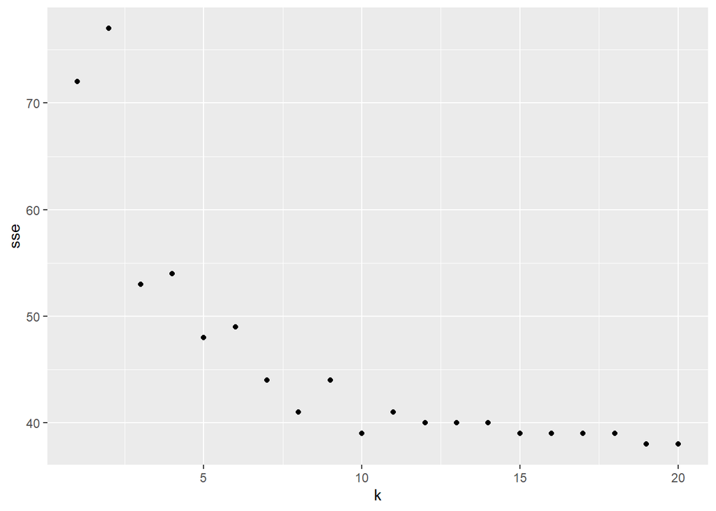

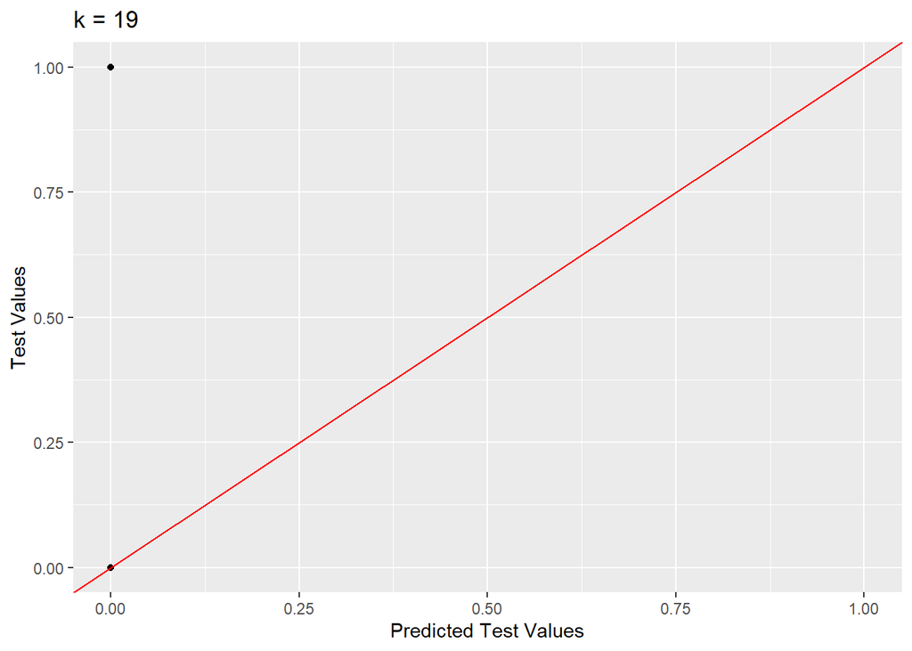

This gave us a `R^2` and sum squared error as follows:

```
## [1] "Sum Squared Error: 38"
```

```
## [1] "R Squared -0.0402969247083773"
```

When using a k Nearest Neighbor (kNN) approach to predict if a patient would have a stroke, we were unable to achieve a positive `R^2`. The kNN model uses a majority vote model in classification. It is very rare that a patient has a stroke to begin with (3-5% in the sample data) so most of the time a majority vote will lead to a negative stroke prediction. Because of this, the model almost always predicted that no one in the test set would have a stroke. In the cases where it did make predictions about some patients having a stroke, it was often over-sensitive and would predict a much larger percentage than the 3-5% that actually existed in the training set. Because this is a classification problem, and because such a small number of people in the dataset actually had a stroke, kNN was not an effective model for this lab.